# Intro

# Other methods

### One-time elimination, using pairwise correlations

First, get the top performing model in each fold, then calculate the average feature importance across these top-performing folds

```r
# get avg feature importance across top-performing folds
  rfe1 |>
    group_by(iteration) |>
    filter(classif.auc == max(classif.auc)) |>
    select(iteration, importance, features) |>
    mutate(
      importance = str_split(importance, ","),
      features   = str_split(features, ",")
    ) |>
    unnest(c(importance, features)) |>
    mutate(importance = as.numeric(importance)) |>
    group_by(features) |>
    summarize(avg_importance = mean(importance)) |>
    arrange(desc(avg_importance))
```

```
## # A tibble: 10 × 2
##    features avg_importance
##    <chr>             <dbl>
##  1 AWEI              316.
##  2 NDRE              197.
##  3 NDMI1             194.
##  4 OSAVI              85.0
##  5 NDVI               75.7
##  6 TCW                57.5
##  7 TCG                52.9
##  8 VH                 48.1
##  9 VV                 46.7
## 10 VVVH_rt            26.6
```

Now, eliminate redundant features: keep the feature with the higher performance

```r
# correlation matrix
train |>
  dplyr::select(all_of(full_featureset)) |>
  cor()
```

```
##                  VV          VH     VVVH_rt        AWEI         TCW      NDMI1
## VV       1.00000000  1.00000000  0.99999884 -0.05097912 -0.04071210 0.02958211
## VH       1.00000000  1.00000000  0.99999883 -0.05097652 -0.04070937 0.02958277
## VVVH_rt  0.99999884  0.99999883  1.00000000 -0.05110140 -0.04089654 0.02937080
## AWEI    -0.05097912 -0.05097652 -0.05110140  1.00000000  0.98873372 0.21103581
## TCW     -0.04071210 -0.04070937 -0.04089654  0.98873372  1.00000000 0.31830902
## NDMI1    0.02958211  0.02958277  0.02937080  0.21103581  0.31830902 1.00000000
## NDRE     0.12496604  0.12496394  0.12479969 -0.48881537 -0.42058431 0.45209746
## NDVI     0.15255871  0.15255725  0.15230902 -0.32158202 -0.27430147 0.35140091
## TCG      0.13892393  0.13892518  0.13847401  0.32706767  0.38261445 0.43584260
## OSAVI    0.16379126  0.16378998  0.16351298 -0.41916103 -0.35069742 0.37283936
##               NDRE       NDVI       TCG      OSAVI
## VV       0.1249660  0.1525587 0.1389239  0.1637913
## VH       0.1249639  0.1525573 0.1389252  0.1637900
## VVVH_rt  0.1247997  0.1523090 0.1384740  0.1635130
## AWEI    -0.4888154 -0.3215820 0.3270677 -0.4191610
## TCW     -0.4205843 -0.2743015 0.3826144 -0.3506974
## NDMI1    0.4520975  0.3514009 0.4358426  0.3728394
## NDRE     1.0000000  0.8094662 0.3833870  0.8253503
## NDVI     0.8094662  1.0000000 0.6064274  0.9168934
## TCG      0.3833870  0.6064274 1.0000000  0.6625824
## OSAVI    0.8253503  0.9168934 0.6625824  1.0000000
```

ok correlations include:

- VV, VH, and VV/VH are correlated –> remove VVVH_rt and VV
- AWEI and TCW –> remove TCW
- NDVI and OSAVI –> remove NDVI

This is super quick and we end up with a totally fine featureset: AWEI, NDRE, NDMI1, OSAVI, TCG, VH. From here, maybe we’d decide to drop the lower-importance variables (TCG and VH). I wonder if there’s a popular threshold for what “low importance” is…

This is really similar to my method, except it assumes feature rankings don’t shuffle when we drop another feature. In that way, I would argue it’s a bit less robust. But, I appreciate how fast this is, and it allows a similar level of manual choice.

### Sequential forward selection

Megan Podolinsky in our lab uses this method. More info [here](https://mlr3book.mlr-org.com/chapters/chapter6/feature_selection.html#sec-fs-wrapper-example)

```r
set.seed(123)

# set up task
task <-
  train |>
  dplyr::select(all_of(full_featureset), type, block) |>
  dplyr::mutate(type=as.factor(type)) |>
  mlr3::as_task_classif(target="type",
                        positive="wet")

# instantiate leave-one-block-out resampling method
rsmp_lobo <- mlr3::rsmp("loo")
task$set_col_roles("block", add_to = "group")
rsmp_lobo$instantiate(task)

# limit task to our predictors
task <- task$select(full_featureset)

# specify algorithm - here I use random forest
lrn_rf = mlr3::lrn("classif.ranger",
                   predict_type = "prob",
                   importance = "impurity",
                   num.trees = 500,
                   max.depth = 10)

# set up the feature selection process
instance <- fselect(
  fselector = fs("sequential", strategy = "sfs"), ## SFS, instead of RFE!
  task = task,
  learner = lrn_rf,
  resampling = rsmp_lobo,
  measure = msr("classif.auc"),
  terminator = trm("stagnation", iters = 50, threshold = 1e-5), # stops when no improvement in the past 50 iterations
  store_benchmark_result = TRUE
)

saveRDS(instance, here("feature_selection_for_lab/data/rfe_results/sfs_instance.rds"))
```

The SFS output shows how features were added, considering all folds (mean performance across folds determines the selection step). So, there’s no iteration-level archive of choice.

```r
sfs_featureset <- instance$result_feature_set
sfs_featureset
```

```
## [1] "AWEI"  "NDMI1" "NDRE"  "NDVI"  "TCG"   "VH"    "VV"
```

Visualize results: with our mlr3 tuning instance, we can take advantage of some “autoplots”. They’re a bit harder to customize, but they’re easy to use. This one shows how the selector added features (from left to right). We can see that the first feature alone has a performance of 0.87, and the second improves it to 0.90.

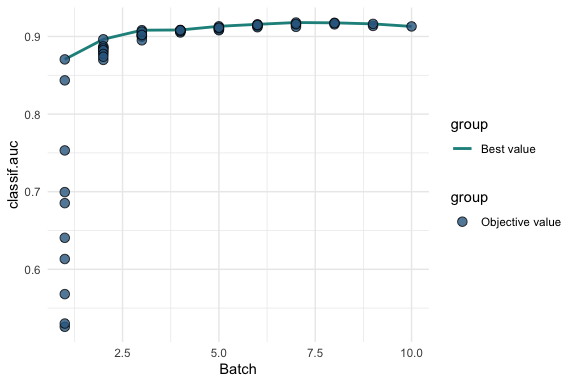

```r
# check out documentation:
# ?mlr3viz::autoplot.TuningInstanceBatchSingleCrit

mlr3viz::autoplot(instance, type = "performance") +
  ggplot2::theme_minimal()
```

It looks like the first 3 features do pretty well! To figure out which three these are, we can parse the instance archive:

```r
sfs_results = as.data.table(instance$archive)

# first feature --> AWEI wins
sfs_results[batch_nr == 1, ] |> arrange(desc(classif.auc)) |> select(features, classif.auc)
```

```
##     features classif.auc
##       <list>       <num>
##  1:     AWEI   0.8704881
##  2:      TCW   0.8434806
##  3:     NDRE   0.7531912
##  4:    OSAVI   0.6994647
##  5:      TCG   0.6852417
##  6:    NDMI1   0.6405760
##  7:     NDVI   0.6132620
##  8:       VV   0.5680106
##  9:  VVVH_rt   0.5301149
## 10:       VH   0.5259107
```

```r
# second feature --> NDRE gets second
sfs_results[batch_nr == 2, ] |> arrange(desc(classif.auc)) |> select(features, classif.auc)
```

```
##        features classif.auc
##          <list>       <num>
## 1:    AWEI,NDRE   0.8964014
## 2:   AWEI,OSAVI   0.8873106
## 3:   AWEI,NDMI1   0.8857268
## 4:     AWEI,TCG   0.8846032
## 5:      AWEI,VH   0.8823582
## 6:    AWEI,NDVI   0.8799142
## 7:      AWEI,VV   0.8774375
## 8: AWEI,VVVH_rt   0.8739332
## 9:     AWEI,TCW   0.8698615
```

```r
# second feature --> VH gets third
sfs_results[batch_nr == 3, ] |> arrange(desc(classif.auc)) |> select(features, classif.auc)
```

```
##             features classif.auc
##               <list>       <num>
## 1:      AWEI,NDRE,VH   0.9081194
## 2:      AWEI,NDRE,VV   0.9062598
## 3:     AWEI,NDRE,TCG   0.9035144
## 4: AWEI,NDRE,VVVH_rt   0.9020038
## 5:   AWEI,NDMI1,NDRE   0.9019743
## 6:   AWEI,NDRE,OSAVI   0.9008770
## 7:    AWEI,NDRE,NDVI   0.8997219
## 8:     AWEI,NDRE,TCW   0.8950541
```

Honestly, I like these 3 (AWEI, NDRE, VH). They’re super complimentary, and they make total sense to me.

Notice how it barely matters what our 2nd feature is - whether we use NDRE, OSAVI, NDMI1, TCG, VH, the AUC difference is 0.014. Same thing for our 3rd feature. This demonstrates how, after the first feature captures most of the signal, additional features contribute only marginal gains, and the model’s performance is relatively insensitive to which specific feature is chosen at that stage.

### Lasso

My partner Andrew is a data scientist who uses lasso for feature selection. I didn’t have time to look into this, but may be useful…

# Random thoughts

- **Hellinger Distance** is a useful node splitting criterion that reduces bias towards the majority class, in imbalanced training sets